# Coursera/Swiftkey Capstone Milestone Report

Don Martin

August 6, 2017

## Introduction

The objective of the Coursera/Swiftkey Capstone project is to apply the skills and techniques learned throughout the program toward building a next word prediction application to take a phrase (of one or more words) as input then predict **the next word** as output. This milestone report will walk through my journey, observations and findings from the **exploration** of SwiftKey data to be used for the project. It will conclude with some thoughts on next steps in this process. The milestone report will conclude with some thoughts on next steps in this process.

*A note regarding this analysis. During the research for this project, memory management in R needed to be addressed for N-Gram analysis to be handled by my machine. These included releasing variables, and garbage collection. I have hidden this r code in this paper in the interest of readability.*

## Exploratory Analysis

The following steps were performed in the Exploratory Data Analysis thus far in the project.

1. Obtain, Download, Unpack, and Load the US English Swiftkey samples
2. Capture Summaries of the Original Raw Data Files
3. Build a corpus from a sample of US English text
4. Clean the corpus and filter profanity
5. Build N-Gram tokens (Uni-Gram, Bi-Gram, and Tri-Gram)
6. Present N-Grams for analysis

This section will walk through and demonstrate key elements of the code used so the reader can re-produce the results. It will also document some of the decisions made along the journey.

### 1. Obtain, Download, and Unpack the Swiftkey corpus

Large databases comprising of text in a target language are commonly used when generating language models for various purposes. The HC Corpora to be used for this project contains twelve corpora divided by blog, news, and twitter samples in four languages (English, German, Russian and Finnish). The code below was used to obtain the sample.

```r
  zipFile   <- "Coursera-SwiftKey.zip"
  unZipDir  <- "./final/en_US/en_US.blogs.txt"
  UrlAddr   <- "https://d396qusza40orc.cloudfront.net/dsscapstone/dataset/Coursera-SwiftKey.zip"

  # Execute the download
    if( !file.exists (zipFile) ){ download.file(UrlAddr, zipFile) }

  # Unpack the zipFile
    if( !file.exists (unZipDir) ){ unzip(zipFile) }
```

*This zipfile is 561,193 KB in size and takes a while to download. The above code only performs the download if necessary.*

The unzipped file is a directory/folder called final, with four subdirectories;**de_DE** (Germain), **fi_FI** (Finnish), and **ru_RU** (Russian) and **en_US** (Americain English) containing the following text to be analyzed;

- en_US.blogs.txt - Samples of blog postings
- en_US.news.txt - Samples of online news articles
- en_US.twitter.txt - Sample tweets

The code below is used to load the samples for analysis in R. The files are read line by line using UTF (Universal Character Set+ Transformation Format-8-bit) capable of encoding all possible characters. Notice the news file was opened in binary mode to overcome several character issues encountered during research.

```r
  # Load "./final/en_US/en_US.blogs.txt"
    blogLines <- readLines("./final/en_US/en_US.blogs.txt",encoding="UTF-8",warn=FALSE,skipNul = TRUE)

  # Load "./final/en_US/en_US.twitter.txt"
    twitLines <- readLines("final/en_US/en_US.twitter.txt",encoding="UTF-8",warn=FALSE,skipNul = TRUE)

  # Load "./final/en_US/en_US.news.txt" using binary mode as there are special character issues
    con       <- file("final/en_US/en_US.news.txt",open="rb")
    newsLines <- readLines(con,encoding="UTF-8",warn=FALSE,skipNul = TRUE)
    close(con)
```

### 2. Capture Summaries of the Original Raw Data Files

With the data loaded, the following code is used to make some initial observations regarding the data.

```r
  suppressMessages( library(stringi))       # For fast text/string manipulation

  # Capture file size in MB
    blogMB <- round((file.info( "./final/en_US/en_US.blogs.txt" )$size   / 1024^2)* 0.01, digits = 2)
    twitMB <- round((file.info( "./final/en_US/en_US.twitter.txt" )$size / 1024^2)* 0.01, digits = 2)
    newsMB <- round((file.info( "./final/en_US/en_US.news.txt" )$size    / 1024^2)* 0.01, digits = 2)

  # Capture Length of the loaded String vectors
    blogLC <- length(blogLines)
    twitLC <- length(twitLines)
    newsLC <- length(newsLines)

  # Capture the number of words in each string vector
    blogWC <- sum(stri_count_words(blogLines))
    twitWC <- sum(stri_count_words(twitLines))
    newsWC <- sum(stri_count_words(newsLines))

  # Capture the number of words in each string vector
    fileStats <- data.frame(
      Text_Sample = c( "Blogs", "News", "Twitter"),
      Size_MB  = c(  blogMB,  newsMB, twitMB  ),
      Lines    = c(  blogLC,  newsLC, twitLC  ),
      Words    = c(  blogWC,  newsWC, twitWC  ))
    fileStats
```

```
##   Text_Sample Size_MB   Lines    Words
## 1       Blogs    2.00  899288 37546246
## 2        News    1.96 1010242 34762395
## 3     Twitter    1.59 2360148 30093410
```

**Sample Blog Text**

```r
  tail(blogLines)
```

```
## [1] "He's really making good progress and we have several big piles that will need to be burned come spring. This isn't a true before and after, but here is a shot of what he's starting with and how well he cleans it up (just not the same spot)."
## [2] "The hulking mass of unfinished brick and concrete at 20-13 35th St. is so unsightly, it became a poster child for zoning reform."
## [3] "The 2004 IIFA award ceremony witnessed a contingent of over 450 stars, celebrities, cricketers, industrialists and government leaders over the festive weekend."
## [4] "Plus, I have also been allowing myself not to get stressed over things that have not been done! If the ironing is not done right now, its not the end of the world! If that phone call is made tomorrow rather than today, then thats OK too! Living in the moment and allowing myself the time to g…
## [5] "(5) What's the barrier to entry and why is the business sustainable?"
## [6] "In response to an over-whelming number of comments we sat down and created a list of do (s) and dont (s)  these recommendations are easy to follow and except for - adding some herbs to your rinse . So lets get begin"
```

**Sample News Text**

```r
  tail(newsLines)
```

```
## [1] "Most of the those turned down for ARC loans probably don't have a prior relationship with the bank, Merski said. He thinks the loans work best when the bank knows the business, its market and how it has performed."
## [2] "Serve a taste of spring: Chop fresh vegetables, olives, cheeses and some grilled chicken. Set out a selection of salad dressings, and let guests assemble their own chopped salads. These numbered jars hold the dressings in style, $5 each at Anthropologie. See anthropologie.com for stores."
## [3] "The complaint alleges that Kuvan Adil Piromari, 42, of U.S. Driving School in El Cajon, served as a go-between for the applicants and state employees. No one answered the phone at his office."
## [4] "But I'm in the mood. After six or more months of chill and ice crystals in Northeast Ohio, the ground is soft and fragrant. Seemingly overnight, things are growing as if we were in the tropics. We are again producing fruit of the earth: sweet corn, mightily fragrant herbs, deep green and ten…
## [5] "That starts this Sunday at Chivas. The Goats aren't a great team, but they just beat one (a 1-0 win over Salt Lake at Rio Tinto). They also have the one player who can rival Roger Espinoza as \"The Best Guy in MLS That No One Talks About Because He Doesn't Play in New York, LA or the Pacific…
## [6] "The only outwardly religious adornment was a billboard-sized banner with an image of Our Lady of Charity, patron saint of Cuba, hanging on the side of the National Library."
```

**Sample Twitter Text**

```r
  tail(twitLines)
```

```
## [1] "and u didnt give it to him? lol"
## [2] "what's good. I see the success you got poppin in yo area."
## [3] "RT : Consumers are visual. They want data at their finger tips. Mobile is the only way to deliver this, 24/7."
## [4] "u welcome"
## [5] "It is #RHONJ time!!"
## [6] "The key to keeping your woman happy= attention, affection, treat her like a queen and sex her like a pornstar!"
```

### 3. Build a corpus from a sample of US English text

```r
  # Remove Non-ASCII Characters
    blogLines  <- iconv(blogLines, from="latin1", to="ASCII", sub="")
    newsLines  <- iconv(newsLines, from="latin1", to="ASCII", sub="")
    twitLines  <- iconv(twitLines, from="latin1", to="ASCII", sub="")
```

Sampling is done to get a quick analysis on the data, to reduce the time needed for pre-processing, to clean the data as well as tokenizing the words of a corpus into different n-gram. Initially I tried a percentage based sample, but was constrained due to approach and memory. I adjusted the approach to sample 10,000 records from each sample giving a bias towards news and blogs.

```r
   set.seed(349)        # For repeatability
   sampleSize <- 10000

  # Sample each type
    blogLines <- blogLines[sample(1:length(blogLines),sampleSize)]
    newsLines <- newsLines[sample(1:length(newsLines),sampleSize)]
    twitLines <- twitLines[sample(1:length(twitLines),sampleSize)]

  # Concatinate blog, news and twitter into one sample
    sampleDoc <- c(blogLines,newsLines,twitLines)
```

To clean and process the text sample, the tm package will be used. The main structure for managing documents in tm is a Corpus, representing a collection of text documents in this case our sample.

```r
  suppressMessages( library(NLP))           # For Natural Language Processing techniques
  suppressMessages( library(tm))            # For basic text-mining
  suppressMessages( library(qdap))          # For Quantitative analysis of transcripts. (sent_detect)

  # Split text paragraphs into sentences
    sampleDoc <- sent_detect(sampleDoc, language = "en", model = NULL)

  # Create the Corpus from the sample
    docs <- VCorpus(VectorSource(list(sampleDoc)))
```

### 4. Clean the corpus and filter profanity

```r
  suppressMessages( library(SnowballC))     # For Word-Stemming

  # Remove Profanity

    if( !file.exists ("./final/swearWords.txt") ){

         urlAddr <- "http://www.bannedwordlist.com/lists/swearWords.txt"

         download.file(urlAddr, "./final/swearWords.txt")
    }

    if( file.exists ("./final/swearWords.txt") ){
        profanity <- readLines("./final/swearWords.txt")
    }

  # Supporting tm_mapFunctions
    removeURLs <- function(x) gsub("http[[:alnum:]]*", "", x)
    toSpace    <- content_transformer(function(x, pattern) gsub(pattern, " ", x))

  # Remove Meta Characters
    docs <- tm_map(docs, toSpace,"/|@|\\|\\,|\\:|\\&|\\-|\\)|\\(|\\{|\\}|\\[|\\]|\\+|=|~|<|>|\\^")
    docs <- tm_map(docs, content_transformer(removeURLs))         # Remove URLs
    docs <- tm_map(docs, content_transformer(tolower))            # Convert to lower case
    docs <- tm_map(docs, content_transformer(removePunctuation))  # Remove Punctuation
    docs <- tm_map(docs, content_transformer(removeNumbers))      # Remove Numbers
    docs <- tm_map(docs, stripWhitespace)                         # Remove whitespace
    if( file.exists ("./final/swearWords.txt") ){
        profanity <- readLines("./final/swearWords.txt")
        docs <- tm_map(docs, removeWords, profanity)              # Remove profanity
    }
    docs <- tm_map(docs, stemDocument, language="en")             # Stemming document
    docs <- tm_map(docs, PlainTextDocument)                       # Create PlainTextDocument
```

### 5. Build N-Gram tokens (Uni-Gram, Bi-Gram, and Tri-Gram)

The following codes compute word frequencies for each document and orders them from largest to smallest. A document-term matrix or term-document matrix (TDM) is a mathematical matrix that describes the frequency of terms that occur in a collection of documents. In a document-term matrix, rows correspond to documents in the collection and columns correspond to terms (source: Wikipedia). For this analysis, only 1-gram, 2-gram, and 3-gram tokenizers are used. Sparse words are removed and a word-frequency list for each n-gram. Word-frequency data frames are produced for the top 25 to be used for plotting and analysis. This section leverages the **RWeka** package.

```r
    suppressMessages( library(RWeka))         # For N-gram generation and tokenization

 # Uni-GramTokenizer Functions
  # Create TermDocumentMatrix for Uni-grams
    UnigramTokenizer <- function(x) NGramTokenizer(x, Weka_control(min = 1, max = 1))
    TdmUni           <- TermDocumentMatrix(docs,
                                           control = list(tokenize = UnigramTokenizer))

  # TermDocumentMatrix Processing
    TdmUni  <- removeSparseTerms(TdmUni, 0.1)     # Remove Sparse Terms
    freqUni <- rowSums(as.matrix(TdmUni))         # Calculate Uni-Gram frequency
    freqUni <- sort(freqUni, decreasing = TRUE)   # SortUni-Gram frequency


# Bi-GramTokenizer Functions
  # Create TermDocumentMatrix for Bi-grams
    BigramTokenizer  <- function(x) NGramTokenizer(x, Weka_control(min = 2, max = 2))
    TdmBi            <- TermDocumentMatrix(docs,
                                           control = list(tokenize = BigramTokenizer))
  # TermDocumentMatrix Processing
    TdmBi   <- removeSparseTerms(TdmBi, 0.1)     # Remove Sparse Terms
    freqBi  <- rowSums(as.matrix(TdmBi))         # Calculate Bi-Gram frequency
    freqBi  <- sort(freqBi,  decreasing = TRUE)  # Sort  Bi-Gram frequency


# Tri-GramTokenizer Functions
  # Create TermDocumentMatrix for Tri-grams
    TrigramTokenizer  <- function(x) NGramTokenizer(x, Weka_control(min = 3, max = 3))
    TdmTri            <- TermDocumentMatrix(docs,
                                           control = list(tokenize = TrigramTokenizer))
  # TermDocumentMatrix Processing
    TdmTri   <- removeSparseTerms(TdmTri, 0.1)     # Remove Sparse Terms
    freqTri  <- rowSums(as.matrix(TdmTri))         # Calculate Tri-Gram frequency
    freqTri  <- sort(freqTri,  decreasing = TRUE)  # Sort  Tri-Gram frequency
```

### 6. Present N-Grams for analysis

The corpus data is displayed below using word clouds, an effective means of displaying word frequencies. The most frequent words are displayed in respect to their size and centralization. One word cloud is plotted for each data type

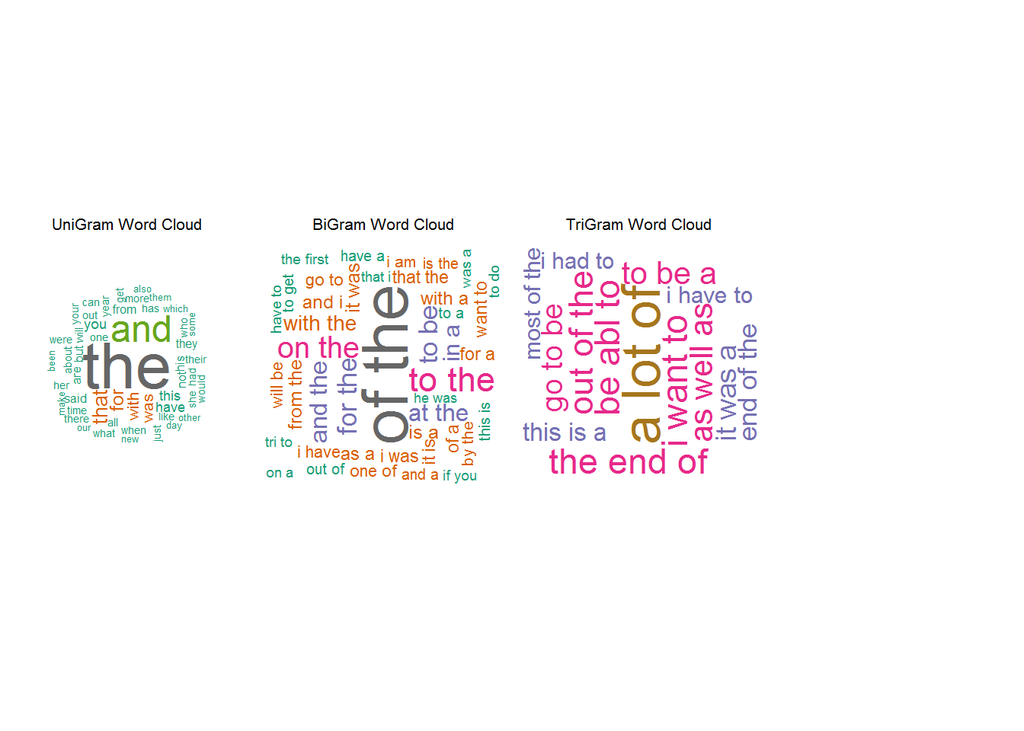

The bar graphs are presented below to provide a better sense of the N-Grams frequency. The Uni-Gram graph includes an example of the code used. The the remaining graphs use similar code not shown.

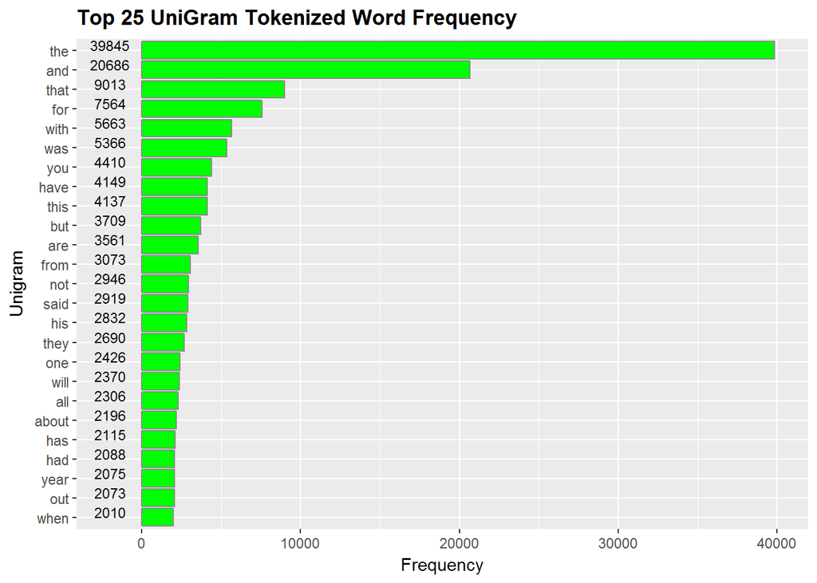

```r
suppressMessages( library(ggplot2))       # For plotting elegant charts,graphs

# Select the top 25 Uni-Grams for plotting
  dfUni25       <- data.frame("Term"=names(head(freqUni,25)),
                               "Frequency"=head(freqUni,25))
  dfUni25$Term1 <- reorder(dfUni25$Term, dfUni25$Frequency)

  UniPlot <-
         ggplot(dfUni25, aes(x = Term1, y = Frequency))                                   +
         geom_bar(stat = "identity", color="gray55", fill="green")                        +
         geom_text(data=dfUni25,aes(x=Term1,y=-2000,label=Frequency),vjust=0, size=3)     +
         xlab("Unigram")                                                                  +
         ylab("Frequency")                                                                +
         ggtitle("Top 25 UniGram Tokenized Word Frequency")                               +
         theme(plot.title = element_text(lineheight=.8, face="bold"))                     +
         coord_flip()
  print(UniPlot)
```

*The Uni-Gram(word) appearing most often in our sample is **the** with 39845 occurances. This information may not be helpful in predicting the next word, but perhaps provides insight into common words that may be input into our engine.*

[figure not shown]

*Bi-Grams appearing most are phrases like **of the**, **in the**, **to the**, **on the**, **for the**, **at the**, **and the**, **with the**. This information provides some insight into how word pairs can help predict the next word.*

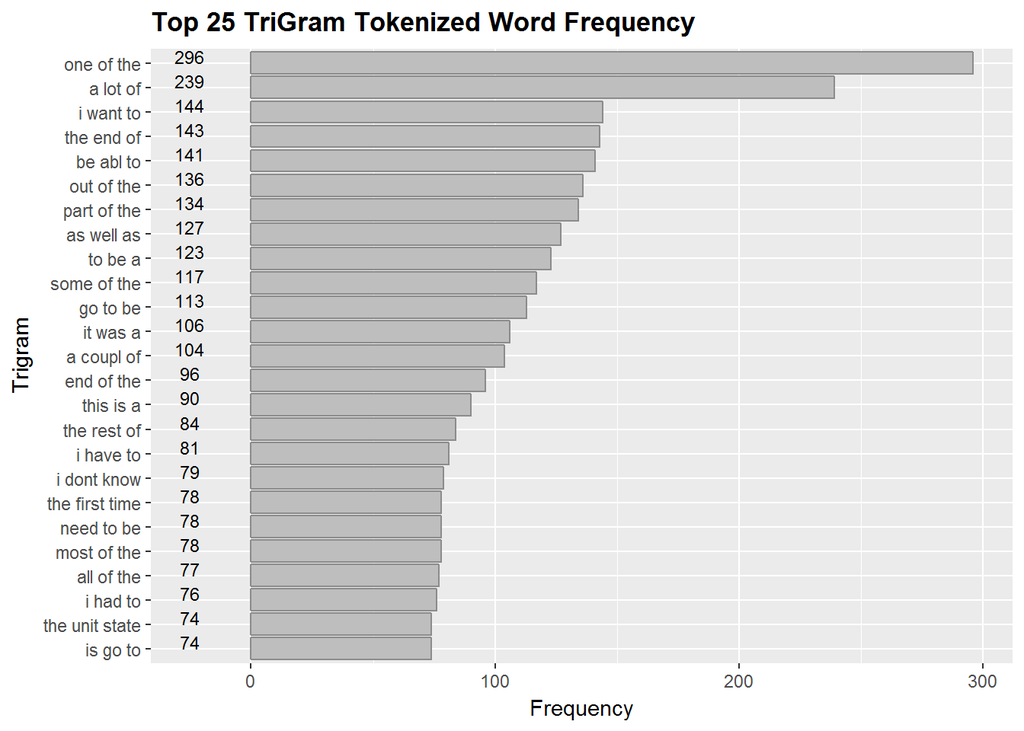

*One of the Tri-Grams appearing most are phrases like **one of the**. Tri-grams occur less frequently in our sample than Bi-Grams, which is to be expected.*

## Next Steps

With the initial exploration, complete, the next is to step build an algorithm to predict the next word, based on the n-gram models. The algorithm involves building lookups for each n-gram, using them to predict the next word in a sentence. The process will assume the whole English language is possible input. A shiny app can be built demonstrating the predict next word algorithm.